# 13. Calibrationless CS-pMR image reconstruction from undersampled Cartesian data

## Generate the kspace

From the 2D brain slice and the acquisition mask, we retrospectively undersample the k-space using a cartesian acquisition mask We then reconstruct the zero order solution as a baseline

```python
# 2. Define the Fourier operator (FFT)

# Get the locations of the kspace samples and the associated observations
fourier_op = FFT(mask=mask, shape=image.shape,
                 n_coils=cartesian_ref_image.shape[0])

# 3. Generate the undersampled k-space data
'''
.op(cartesian_ref_image) applies the forward Fourier transform (FFT) only at the sampled locations corresponding to the mask
kspace_obs is a subsampled k-space representation of the image with size (32, 512, 512) .
'''
kspace_obs = fourier_op.op(cartesian_ref_image)
```

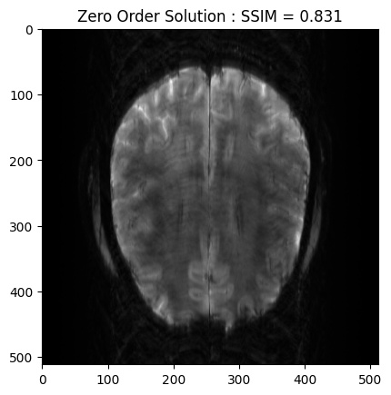

```python
# Zero order solution

# Perform the inverse Fourier transform
zero_soln = np.linalg.norm(fourier_op.adj_op(kspace_obs), axis=0)
base_ssim = ssim(zero_soln, image)
plt.imshow(np.abs(zero_soln), cmap='gray')
plt.title('Zero Order Solution : SSIM = ' + str(np.around(base_ssim, 3)))
plt.show()
```

$\leadsto$ Here we apply the Fourier operator and its ajoint to perform the zero order solution :

  where we define the **Fourier transform** (FFT) operator only for the sampled locations corresponding to the `mask` ,

  then we apply this operator to the `image` : `kspace_obs = fourier_op.op(cartesian_ref_image)` to obtain the undersampled k-space obs data.
- To compute the zero order solution, we just apply the ajoint of the operator `zero_soln = np.linalg.norm(fourier_op.adj_op(kspace_obs), axis=0)`, which serves as a basic reconstruction:

## Synthesis formulation: FISTA vs POGM optimization

We now want to refine the zero order solution using a FISTA optimization. The cost function is set to Proximity Cost + Gradient Cost

```python
# Setup the operators
linear_op = WaveletN(
    wavelet_name='sym8',
    nb_scale=4,
    n_coils=cartesian_ref_image.shape[0],
)
coeffs = linear_op.op(cartesian_ref_image)
regularizer_op = GroupLASSO(weights=6e-8)
```

## Setup reconstructor:

```python
# Setup Reconstructor
reconstructor = CalibrationlessReconstructor(
    fourier_op=fourier_op,
    linear_op=linear_op,
    regularizer_op=regularizer_op,
    gradient_formulation='synthesis',
    verbose=1,
)
```

```
WARNING: Making input data immutable.
```

```
Lipschitz constant is 1.0999999344348907
```

```
WARNING: Making input data immutable.
```

```
 - mu:  6e-08
 - lipschitz constant:  1.0999999344348907
 - data:  (512, 512)
 - wavelet:  <mri.operators.linear.wavelet.WaveletN object at 0x7f4bd4ba5790> - 4
 - max iterations:  100
 - image variable shape:  (512, 512)
 - alpha variable shape:  (32, 291721)
----------------------------------------
Starting optimization...
```

```
 - final iteration number:  100
 - final log10 cost value:  6.0
 - converged:  False
Done.
Execution time:  115.74814624199644  seconds
----------------------------------------
```

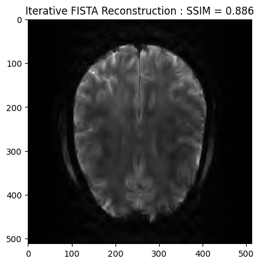

```python
# Run the FISTA reconstruction and view results
image_rec, costs, metrics = reconstructor.reconstruct(
    kspace_data=kspace_obs,
    optimization_alg='fista',
    num_iterations=100,
)
image_rec = np.linalg.norm(image_rec, axis=0)
recon_ssim = ssim(image_rec, image)
plt.imshow(np.abs(image_rec), cmap='gray')
plt.title('Iterative FISTA Reconstruction : SSIM = ' + str(np.around(recon_ssim, 3)))
plt.show()
```

## POGM optimization

```
 - mu:  6e-08
 - lipschitz constant:  1.0999999344348907
 - data:  (512, 512)
 - wavelet:  <mri.operators.linear.wavelet.WaveletN object at 0x7f4bd4ba5790> - 4
 - max iterations:  100
 - image variable shape:  (32, 512, 512)
----------------------------------------
Starting optimization...
```

```
 - final iteration number:  100
 - final log10 cost value:  6.0
 - converged:  False
Done.
Execution time:  132.82787203100452  seconds
----------------------------------------
```

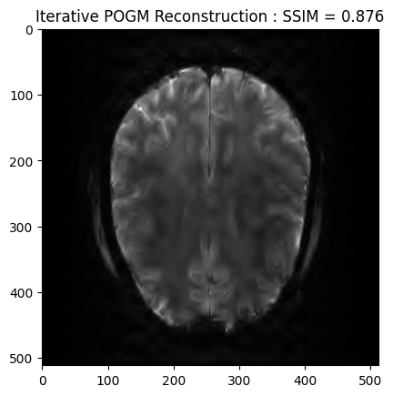

```python
# Run the POGM reconstruction and view results
image_rec2, costs, metrics = reconstructor.reconstruct(
    kspace_data=kspace_obs,
    optimization_alg='pogm',
    num_iterations=100,
)
image_rec2 = np.linalg.norm(image_rec2, axis=0)
recon2_ssim = ssim(image_rec2, image)
plt.imshow(np.abs(image_rec2), cmap='gray')
plt.title('Iterative POGM Reconstruction : SSIM = ' + str(np.around(recon2_ssim, 3)))
plt.show()
```

```python
# Setup the operators
linear_op = WaveletN(
    wavelet_name='sym8',
    nb_scale=4,
    n_coils=cartesian_ref_image.shape[0],
)
coeffs = linear_op.op(cartesian_ref_image)
regularizer_op = OWL(
    alpha=1.05e-8,
    beta=0,
    mode='band_based',
    n_coils=cartesian_ref_image.shape[0],
    bands_shape=linear_op.coeffs_shape,
)
# Setup Reconstructor
reconstructor = CalibrationlessReconstructor(
    fourier_op=fourier_op,
    linear_op=linear_op,
    regularizer_op=regularizer_op,
    gradient_formulation='synthesis',
    verbose=1,
)
```

```
WARNING: Making input data immutable.
```

```
Lipschitz constant is 1.1
```

```
 - mu:  [<modopt.opt.proximity.OrderedWeightedL1Norm object at 0x7f4bd4bb05d0>, <modopt.opt.proximity.OrderedWeightedL1Norm object at 0x7f4bd4bcd450>, <modopt.opt.proximity.OrderedWeightedL1Norm object at 0x7f4bd420b8d0>, <modopt.opt.proximity.OrderedWeightedL1Norm object at 0x7f4bd4209790>, <modopt…
 - lipschitz constant:  1.1
 - data:  (512, 512)
 - wavelet:  <mri.operators.linear.wavelet.WaveletN object at 0x7f4bd4b99c10> - 4
 - max iterations:  100
 - image variable shape:  (512, 512)
 - alpha variable shape:  (32, 291721)
----------------------------------------
Starting optimization...
```

```
 - final iteration number:  100
 - final log10 cost value:  6.0
 - converged:  False
Done.
Execution time:  173.98121633499977  seconds
----------------------------------------
```

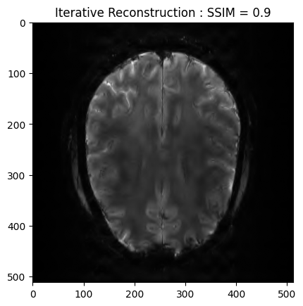

```python
# Run the FISTA reconstruction and view results
image_rec, costs, metrics = reconstructor.reconstruct(
    kspace_data=kspace_obs,
    optimization_alg='fista',
    num_iterations=100,
)
image_rec = np.linalg.norm(image_rec, axis=0)
recon_ssim = ssim(image_rec, image)
plt.imshow(np.abs(image_rec), cmap='gray')
plt.title('Iterative Reconstruction : SSIM = ' + str(np.around(recon_ssim, 2)))
plt.show()
```

GroupLASSO

```python
linear_op = WaveletN(
    wavelet_name='sym8',
    nb_scale=4,
    n_coils=cartesian_ref_image.shape[0],
)
#padding_mode="periodization"

regularizer_op = GroupLASSO(6e-8)
```

```python
reconstructor = CalibrationlessReconstructor(
    fourier_op=fourier_op,
    linear_op=linear_op,
    regularizer_op=regularizer_op,
    gradient_formulation='analysis',
    verbose=1,
)
```

```
WARNING: Making input data immutable.
```

```
Lipschitz constant is 1.1
```

```python
import pysap
```

```
WARNING: <class 'mri.operators.linear.wavelet.WaveletN'> does not inherit an operator parent.
```

```
 - mu:  6e-08
 - lipschitz constant:  1.1
 - tau:  0.9523809433107514
 - sigma:  0.5
 - rho:  1.0
 - std:  None
 - 1/tau - sigma||L||^2 >= beta/2:  True
 - data:  (512, 512)
 - wavelet:  <mri.operators.linear.wavelet.WaveletN object at 0x7f4bd425cf10> - 4
 - max iterations:  100
 - number of reweights:  0
 - primal variable shape:  (32, 512, 512)
 - dual variable shape:  (32, 291721)
----------------------------------------
Starting optimization...
```

```
 - final iteration number:  100
 - final cost value:  1000000.0
 - converged:  False
Done.
Execution time:  129.45200876399758  seconds
----------------------------------------
```

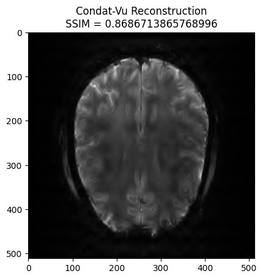

```python
x_final, costs, metrics = reconstructor.reconstruct(
    kspace_data=kspace_obs,
    optimization_alg='condatvu',
    num_iterations=100,
)

image_rec = pysap.Image(data=np.sqrt(np.sum(np.abs(x_final)**2, axis=0)))
recon_ssim = ssim(image_rec, image)

plt.imshow(np.abs(image_rec), cmap='gray')
plt.title('Condat-Vu Reconstruction\nSSIM = ' + str(recon_ssim))
plt.show()
```

OWL

```python
from mri.operators import NonCartesianFFT, WaveletUD2, WaveletN
```

```python
# Undecimated Wavelets
'''
linear_op = WaveletUD2(
    wavelet_id=24,
    nb_scale=4,
    n_coils=cartesian_ref_image.shape[0],
)
'''
```

```
'\nlinear_op = WaveletUD2(\n    wavelet_id=24,\n    nb_scale=4,\n    n_coils=cartesian_ref_image.shape[0],\n)\n'
```

```python
#regularizer_op = GroupLASSO(6e-8)
coeffs = linear_op.op(cartesian_ref_image)
regularizer_op = OWL(
    alpha=1.05e-8,
    beta=0,
    mode='band_based',
    n_coils=cartesian_ref_image.shape[0],
    bands_shape=linear_op.coeffs_shape,
)
```

```python
reconstructor = CalibrationlessReconstructor(
    fourier_op=fourier_op,
    linear_op=linear_op,
    regularizer_op=regularizer_op,
    gradient_formulation='analysis',
    verbose=1,
)
```

```
WARNING: Making input data immutable.
```

```
Lipschitz constant is 1.1000001311302186
```

```
WARNING: <class 'mri.operators.linear.wavelet.WaveletN'> does not inherit an operator parent.
```

```
 - mu:  [<modopt.opt.proximity.OrderedWeightedL1Norm object at 0x7f4bd4bbf210>, <modopt.opt.proximity.OrderedWeightedL1Norm object at 0x7f4bd4bd5390>, <modopt.opt.proximity.OrderedWeightedL1Norm object at 0x7f4bcb43e2d0>, <modopt.opt.proximity.OrderedWeightedL1Norm object at 0x7f4bcb459390>, <modopt…
 - lipschitz constant:  1.1000001311302186
 - tau:  0.9523808838412695
 - sigma:  0.5
 - rho:  1.0
 - std:  None
 - 1/tau - sigma||L||^2 >= beta/2:  True
 - data:  (512, 512)
 - wavelet:  <mri.operators.linear.wavelet.WaveletN object at 0x7f4bd425cf10> - 4
 - max iterations:  100
 - number of reweights:  0
 - primal variable shape:  (32, 512, 512)
 - dual variable shape:  (32, 291721)
----------------------------------------
Starting optimization...
```

```
 - final iteration number:  100
 - final cost value:  1000000.0
 - converged:  False
Done.
Execution time:  207.19260900700465  seconds
----------------------------------------
```

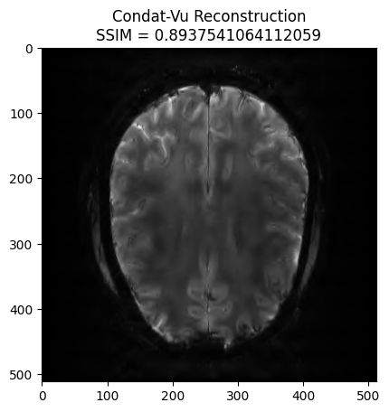

```python
x_final, costs, metrics = reconstructor.reconstruct(
    kspace_data=kspace_obs,
    optimization_alg='condatvu',
    num_iterations=100,
)

image_rec = pysap.Image(data=np.sqrt(np.sum(np.abs(x_final)**2, axis=0)))
recon_ssim = ssim(image_rec, image)

plt.imshow(np.abs(image_rec), cmap='gray')
plt.title('Condat-Vu Reconstruction\nSSIM = ' + str(recon_ssim))
plt.show()
```

**Q1**

- Observe and comment the image quality using calibrationless reconstruction with either the Group-LASSO or the Ordered Weighted L1-norm (OWL) regularization.
- Which one provides the best image quality? Why?

$\leadsto$ First, we try using `linear_op = WaveletUD2`, `gradient_formulation='analysis'` and `optimization_alg='condatvu'`, in `num_iterations=100`, the reconstruction takes approximately 1h30 , having the **lowest** image quality and the computation time is the longest.

```python
import pysap
```

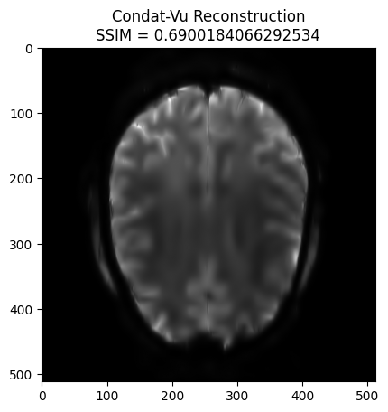

```python
linear_op = WaveletUD2(
    wavelet_id=24,
    nb_scale=4,
    n_coils=cartesian_ref_image.shape[0],
)
coeffs = linear_op.op(cartesian_ref_image)

regularizer_op = OWL(
    alpha=1.05e-8,
    beta=0,
    mode='band_based',
    n_coils=cartesian_ref_image.shape[0],
    bands_shape=linear_op.coeffs_shape,
)

reconstructor = CalibrationlessReconstructor(
    fourier_op=fourier_op,
    linear_op=linear_op,
    regularizer_op=regularizer_op,
    gradient_formulation='analysis',
    verbose=1,
)

x_final, costs, metrics = reconstructor.reconstruct(
    kspace_data=kspace_obs,
    optimization_alg='condatvu',
    num_iterations=100,
)

image_rec = pysap.Image(data=np.sqrt(np.sum(np.abs(x_final)**2, axis=0)))
recon_ssim = ssim(image_rec, image)

plt.imshow(np.abs(image_rec), cmap='gray')
plt.title('Condat-Vu Reconstruction\nSSIM = ' + str(recon_ssim))
plt.show()
```

$\leadsto$ We decide to use `linear_op = WaveletN`, `gradient_formulation='synthesis'` and `optimization_alg='fista'`

GroupLASSO

```
WARNING: Making input data immutable.
```

```
Lipschitz constant is 1.0999999344348907
 - mu:  6e-08
 - lipschitz constant:  1.0999999344348907
 - data:  (512, 512)
 - wavelet:  <mri.operators.linear.wavelet.WaveletN object at 0x7ff5c1dfea10> - 4
 - max iterations:  100
 - image variable shape:  (512, 512)
 - alpha variable shape:  (32, 291721)
----------------------------------------
Starting optimization...
```

```
 - final iteration number:  100
 - final log10 cost value:  6.0
 - converged:  False
Done.
Execution time:  131.70454503200017  seconds
----------------------------------------
```

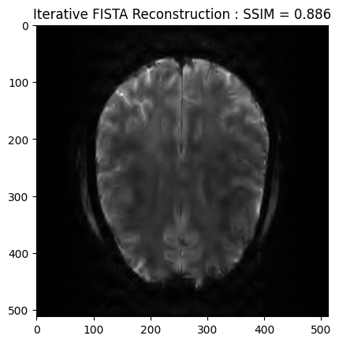

```python
# Setup the operators
linear_op = WaveletN(
    wavelet_name='sym8',
    nb_scale=4,
    n_coils=cartesian_ref_image.shape[0],
)
coeffs = linear_op.op(cartesian_ref_image)
regularizer_op = GroupLASSO(weights=6e-8)

# Setup Reconstructor
reconstructor = CalibrationlessReconstructor(
    fourier_op=fourier_op,
    linear_op=linear_op,
    regularizer_op=regularizer_op,
    gradient_formulation='synthesis',
    verbose=1,
)

# Run the FISTA reconstruction and view results
image_rec, costs, metrics = reconstructor.reconstruct(
    kspace_data=kspace_obs,
    optimization_alg='fista',
    num_iterations=100,
)
image_rec = np.linalg.norm(image_rec, axis=0)
recon_ssim = ssim(image_rec, image)
plt.imshow(np.abs(image_rec), cmap='gray')
plt.title('Iterative FISTA Reconstruction : SSIM = ' + str(np.around(recon_ssim, 3)))
plt.show()
```

OWL

```
WARNING: Making input data immutable.
```

```
Lipschitz constant is 1.1
 - mu:  [<modopt.opt.proximity.OrderedWeightedL1Norm object at 0x7ff5c3b871d0>, <modopt.opt.proximity.OrderedWeightedL1Norm object at 0x7ff5bfc7e7d0>, <modopt.opt.proximity.OrderedWeightedL1Norm object at 0x7ff5bfcf2750>, <modopt.opt.proximity.OrderedWeightedL1Norm object at 0x7ff5bfcf2a50>, <modopt…
 - lipschitz constant:  1.1
 - data:  (512, 512)
 - wavelet:  <mri.operators.linear.wavelet.WaveletN object at 0x7ff5bfcb0610> - 4
 - max iterations:  100
 - image variable shape:  (512, 512)
 - alpha variable shape:  (32, 291721)
----------------------------------------
Starting optimization...
```

```
 - final iteration number:  100
 - final log10 cost value:  6.0
 - converged:  False
Done.
Execution time:  183.59860118600773  seconds
----------------------------------------
```

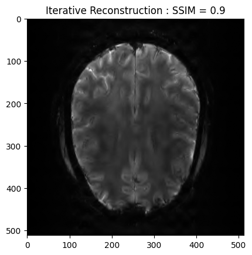

```python
# Setup the operators
linear_op = WaveletN(
    wavelet_name='sym8',
    nb_scale=4,
    n_coils=cartesian_ref_image.shape[0],
)
coeffs = linear_op.op(cartesian_ref_image)
regularizer_op = OWL(
    alpha=1.05e-8,
    beta=0,
    mode='band_based',
    n_coils=cartesian_ref_image.shape[0],
    bands_shape=linear_op.coeffs_shape,
)
# Setup Reconstructor
reconstructor = CalibrationlessReconstructor(
    fourier_op=fourier_op,
    linear_op=linear_op,
    regularizer_op=regularizer_op,
    gradient_formulation='synthesis',
    verbose=1,
)

# Run the FISTA reconstruction and view results
image_rec, costs, metrics = reconstructor.reconstruct(
    kspace_data=kspace_obs,
    optimization_alg='fista',
    num_iterations=100,
)
image_rec = np.linalg.norm(image_rec, axis=0)
recon_ssim = ssim(image_rec, image)
plt.imshow(np.abs(image_rec), cmap='gray')
plt.title('Iterative Reconstruction : SSIM = ' + str(np.around(recon_ssim, 2)))
plt.show()
```

```python
# 导入 MRI 重建运算符
# Package import
from mri.operators import FFT, WaveletN
'''
WaveletN : 正交小波变换（如 Symmlet-8 或 Daubechies），用于 合成公式（Synthesis Formulation） 压缩感知重建。
WaveletUD2 : 未降采样双正交小波变换（Undecimated Bi-Orthogonal Wavelet Transform），用于 分析公式（Analysis Formulation） 压缩感知重建。
'''
# 导入 MRI 处理的实用工具
from mri.operators.utils import convert_mask_to_locations
'''
convert_mask_to_locations ：2D binary mask -> a list of sampled k-space coordinates (x, y)
'''
#  导入 MRI 图像重建器
from mri.reconstructors.utils.extract_sensitivity_maps \
    import get_Smaps, extract_k_space_center_and_locations
from mri.reconstructors import SelfCalibrationReconstructor
'''
get_Smaps ：从 k-space 提取 灵敏度图（Sensitivity Maps），用于 多通道 MRI 重建（pMRI）。
extract_k_space_center_and_locations ：获取 K-space 采样中心，用于自校准（Self-Calibration）。
SelfCalibrationReconstructor ：用于 基于自校准（Self-Calibrated）策略 进行 MRI 图像重建。
'''

# 导入 MRI 样本数据
from pysap.data import get_sample_data

# Third party import
from modopt.math.metrics import ssim
from modopt.opt.linear import Identity
from modopt.opt.proximity import SparseThreshold
'''
ssim : 结构相似性指数（SSIM），用于 评估重建图像的质量，与原始 MRI 进行比较。
Identity : 单位变换（Identity Transformation），即 不对数据做任何变换，在优化过程中常用于保持数据结构。
SparseThreshold : 稀疏阈值运算（L1 正则化 / 软阈值收缩），用于 压缩感知重建中的稀疏性约束。
'''

import numpy as np
import matplotlib.pyplot as plt
```

```python
# 2. Define the Fourier operator (FFT)

# Get the locations of the kspace samples and the associated observations
fourier_op = FFT(mask=mask, shape=image.shape,
                 n_coils=cartesian_ref_image.shape[0])

# 3. Generate the undersampled k-space data
'''
.op(cartesian_ref_image) applies the forward Fourier transform (FFT) only at the sampled locations corresponding to the mask
kspace_obs is a subsampled k-space representation of the image with size (32, 512, 512) .
'''
kspace_obs = fourier_op.op(cartesian_ref_image)
```

```python
import time
```

```python
def reconstruction (regularizer_op_, num_iterations_) :
    if  regularizer_op_ in ["GroupLASSO", "OWL"] :
        time_0 = time.time()
        # Setup the operators
        linear_op = WaveletN(
            wavelet_name='sym8',
            nb_scale=4,
            n_coils=cartesian_ref_image.shape[0],
        )
        coeffs = linear_op.op(cartesian_ref_image)

        if regularizer_op_ == "GroupLASSO" :
            regularizer_op = GroupLASSO(weights=6e-8)
        elif regularizer_op_ == "OWL" :
            regularizer_op = OWL(
                alpha=1.05e-8,
                beta=0,
                mode='band_based',
                n_coils=cartesian_ref_image.shape[0],
                bands_shape=linear_op.coeffs_shape,
            )

        # Setup Reconstructor
        reconstructor = CalibrationlessReconstructor(
            fourier_op=fourier_op,
            linear_op=linear_op,
            regularizer_op=regularizer_op,
            gradient_formulation='synthesis',
            verbose=1,
        )

        # Run the FISTA reconstruction and view results
        image_rec, costs, metrics = reconstructor.reconstruct(
            kspace_data=kspace_obs,
            optimization_alg='fista',
            num_iterations=num_iterations_,
        )
        image_rec = np.linalg.norm(image_rec, axis=0)
        recon_ssim = ssim(image_rec, image)
        time_1 = time.time()

    elif regularizer_op_ == "SparseThreshold" :
        time_0 = time.time()
        linear_op = WaveletN(
            wavelet_name='sym8',
            nb_scale=4,
        )
        regularizer_op = SparseThreshold(Identity(), 1.5e-8, thresh_type="soft")

        # Setup Reconstructor
        reconstructor = SelfCalibrationReconstructor(
            fourier_op=fourier_op,
            linear_op=linear_op,
            regularizer_op=regularizer_op,
            gradient_formulation='synthesis',
            kspace_portion=0.01,
            verbose=1,
        )

        image_rec, costs, metrics = reconstructor.reconstruct(
            kspace_data=kspace_obs,
            optimization_alg='fista',
            num_iterations=num_iterations_,
        )
        recon_ssim = ssim(image_rec, image)
        time_1 = time.time()

    time_computation = time_1 - time_0

    return image_rec, recon_ssim, time_computation
```

```
WARNING: Making input data immutable.
```

```
Lipschitz constant is 1.1
 - mu:  6e-08
 - lipschitz constant:  1.1
 - data:  (512, 512)
 - wavelet:  <mri.operators.linear.wavelet.WaveletN object at 0x7ff5c0ec4850> - 4
 - max iterations:  20
 - image variable shape:  (512, 512)
 - alpha variable shape:  (32, 291721)
----------------------------------------
Starting optimization...
```

```
 - final iteration number:  20
 - final log10 cost value:  6.0
 - converged:  False
Done.
Execution time:  23.59279942198191  seconds
----------------------------------------
```

```
WARNING: Making input data immutable.
```

```
Lipschitz constant is 1.1
 - mu:  [<modopt.opt.proximity.OrderedWeightedL1Norm object at 0x7ff5c10878d0>, <modopt.opt.proximity.OrderedWeightedL1Norm object at 0x7ff5c1451450>, <modopt.opt.proximity.OrderedWeightedL1Norm object at 0x7ff5c1126810>, <modopt.opt.proximity.OrderedWeightedL1Norm object at 0x7ff5c1310b90>, <modopt…
 - lipschitz constant:  1.1
 - data:  (512, 512)
 - wavelet:  <mri.operators.linear.wavelet.WaveletN object at 0x7ff5c0f98a10> - 4
 - max iterations:  20
 - image variable shape:  (512, 512)
 - alpha variable shape:  (32, 291721)
----------------------------------------
Starting optimization...
```

```
 - final iteration number:  20
 - final log10 cost value:  6.0
 - converged:  False
Done.
Execution time:  34.07857509801397  seconds
----------------------------------------
```

```
Lipschitz constant is 1.0983739524034357
 - mu:  1.5e-08
 - lipschitz constant:  1.0983739524034357
 - data:  (512, 512)
 - wavelet:  <mri.operators.linear.wavelet.WaveletN object at 0x7ff5c1279050> - 4
 - max iterations:  20
 - image variable shape:  (512, 512)
 - alpha variable shape:  (291721,)
----------------------------------------
Starting optimization...
```

```
 - final iteration number:  20
 - final log10 cost value:  6.0
 - converged:  False
Done.
Execution time:  11.467041001014877  seconds
----------------------------------------
```

```
WARNING: Making input data immutable.
```

```
Lipschitz constant is 1.0999999344348907
 - mu:  6e-08
 - lipschitz constant:  1.0999999344348907
 - data:  (512, 512)
 - wavelet:  <mri.operators.linear.wavelet.WaveletN object at 0x7ff5c1298310> - 4
 - max iterations:  100
 - image variable shape:  (512, 512)
 - alpha variable shape:  (32, 291721)
----------------------------------------
Starting optimization...
```

```
 - final iteration number:  100
 - final log10 cost value:  6.0
 - converged:  False
Done.
Execution time:  113.60279641102534  seconds
----------------------------------------
```

```
WARNING: Making input data immutable.
```

```
Lipschitz constant is 1.0999999344348907
 - mu:  [<modopt.opt.proximity.OrderedWeightedL1Norm object at 0x7ff5c1451b10>, <modopt.opt.proximity.OrderedWeightedL1Norm object at 0x7ff5c12c9450>, <modopt.opt.proximity.OrderedWeightedL1Norm object at 0x7ff5c13666d0>, <modopt.opt.proximity.OrderedWeightedL1Norm object at 0x7ff5c12d5190>, <modopt…
 - lipschitz constant:  1.0999999344348907
 - data:  (512, 512)
 - wavelet:  <mri.operators.linear.wavelet.WaveletN object at 0x7ff5c1365710> - 4
 - max iterations:  100
 - image variable shape:  (512, 512)
 - alpha variable shape:  (32, 291721)
----------------------------------------
Starting optimization...
```

```
 - final iteration number:  100
 - final log10 cost value:  6.0
 - converged:  False
Done.
Execution time:  169.95869153999956  seconds
----------------------------------------
```

```
Lipschitz constant is 1.0983827475250922
 - mu:  1.5e-08
 - lipschitz constant:  1.0983827475250922
 - data:  (512, 512)
 - wavelet:  <mri.operators.linear.wavelet.WaveletN object at 0x7ff5c13f4d50> - 4
 - max iterations:  100
 - image variable shape:  (512, 512)
 - alpha variable shape:  (291721,)
----------------------------------------
Starting optimization...
```

```
 - final iteration number:  100
 - final log10 cost value:  6.0
 - converged:  False
Done.
Execution time:  56.150758088042494  seconds
----------------------------------------
```

```
WARNING: Making input data immutable.
```

```
Lipschitz constant is 1.1
 - mu:  6e-08
 - lipschitz constant:  1.1
 - data:  (512, 512)
 - wavelet:  <mri.operators.linear.wavelet.WaveletN object at 0x7ff5c1439590> - 4
 - max iterations:  400
 - image variable shape:  (512, 512)
 - alpha variable shape:  (32, 291721)
----------------------------------------
Starting optimization...
```

```
 - final iteration number:  400
 - final log10 cost value:  6.0
 - converged:  False
Done.
Execution time:  455.7087595909834  seconds
----------------------------------------
```

```
WARNING: Making input data immutable.
```

```
Lipschitz constant is 1.1
 - mu:  [<modopt.opt.proximity.OrderedWeightedL1Norm object at 0x7ff5c109f1d0>, <modopt.opt.proximity.OrderedWeightedL1Norm object at 0x7ff5c1139450>, <modopt.opt.proximity.OrderedWeightedL1Norm object at 0x7ff5c153e6d0>, <modopt.opt.proximity.OrderedWeightedL1Norm object at 0x7ff5c1535050>, <modopt…
 - lipschitz constant:  1.1
 - data:  (512, 512)
 - wavelet:  <mri.operators.linear.wavelet.WaveletN object at 0x7ff5c10e2cd0> - 4
 - max iterations:  400
 - image variable shape:  (512, 512)
 - alpha variable shape:  (32, 291721)
----------------------------------------
Starting optimization...
```

```
 - final iteration number:  400
 - final log10 cost value:  6.0
 - converged:  False
Done.
Execution time:  688.5990858930163  seconds
----------------------------------------
```

```
Lipschitz constant is 1.0983756736137944
 - mu:  1.5e-08
 - lipschitz constant:  1.0983756736137944
 - data:  (512, 512)
 - wavelet:  <mri.operators.linear.wavelet.WaveletN object at 0x7ff5c1128710> - 4
 - max iterations:  400
 - image variable shape:  (512, 512)
 - alpha variable shape:  (291721,)
----------------------------------------
Starting optimization...
```

```
 - final iteration number:  400
 - final log10 cost value:  6.0
 - converged:  False
Done.
Execution time:  235.96641186298802  seconds
----------------------------------------
```

```
WARNING: Making input data immutable.
```

```
Lipschitz constant is 1.1
 - mu:  6e-08
 - lipschitz constant:  1.1
 - data:  (512, 512)
 - wavelet:  <mri.operators.linear.wavelet.WaveletN object at 0x7ff5c12c1a10> - 4
 - max iterations:  500
 - image variable shape:  (512, 512)
 - alpha variable shape:  (32, 291721)
----------------------------------------
Starting optimization...
```

```
 - final iteration number:  500
 - final log10 cost value:  6.0
 - converged:  False
Done.
Execution time:  574.003705169016  seconds
----------------------------------------
```

```
WARNING: Making input data immutable.
```

```
Lipschitz constant is 1.1
 - mu:  [<modopt.opt.proximity.OrderedWeightedL1Norm object at 0x7ff5c12e71d0>, <modopt.opt.proximity.OrderedWeightedL1Norm object at 0x7ff5c144e2d0>, <modopt.opt.proximity.OrderedWeightedL1Norm object at 0x7ff5c12b4290>, <modopt.opt.proximity.OrderedWeightedL1Norm object at 0x7ff5c12b4210>, <modopt…
 - lipschitz constant:  1.1
 - data:  (512, 512)
 - wavelet:  <mri.operators.linear.wavelet.WaveletN object at 0x7ff5c12e4d90> - 4
 - max iterations:  500
 - image variable shape:  (512, 512)
 - alpha variable shape:  (32, 291721)
----------------------------------------
Starting optimization...
```

```
 - final iteration number:  500
 - final log10 cost value:  6.0
 - converged:  False
Done.
Execution time:  879.8526554090204  seconds
----------------------------------------
```

```
Lipschitz constant is 1.098389243513933
 - mu:  1.5e-08
 - lipschitz constant:  1.098389243513933
 - data:  (512, 512)
 - wavelet:  <mri.operators.linear.wavelet.WaveletN object at 0x7ff5c12c9790> - 4
 - max iterations:  500
 - image variable shape:  (512, 512)
 - alpha variable shape:  (291721,)
----------------------------------------
Starting optimization...
```

```
 - final iteration number:  500
 - final log10 cost value:  6.0
 - converged:  False
Done.
Execution time:  292.79050998500315  seconds
----------------------------------------
```

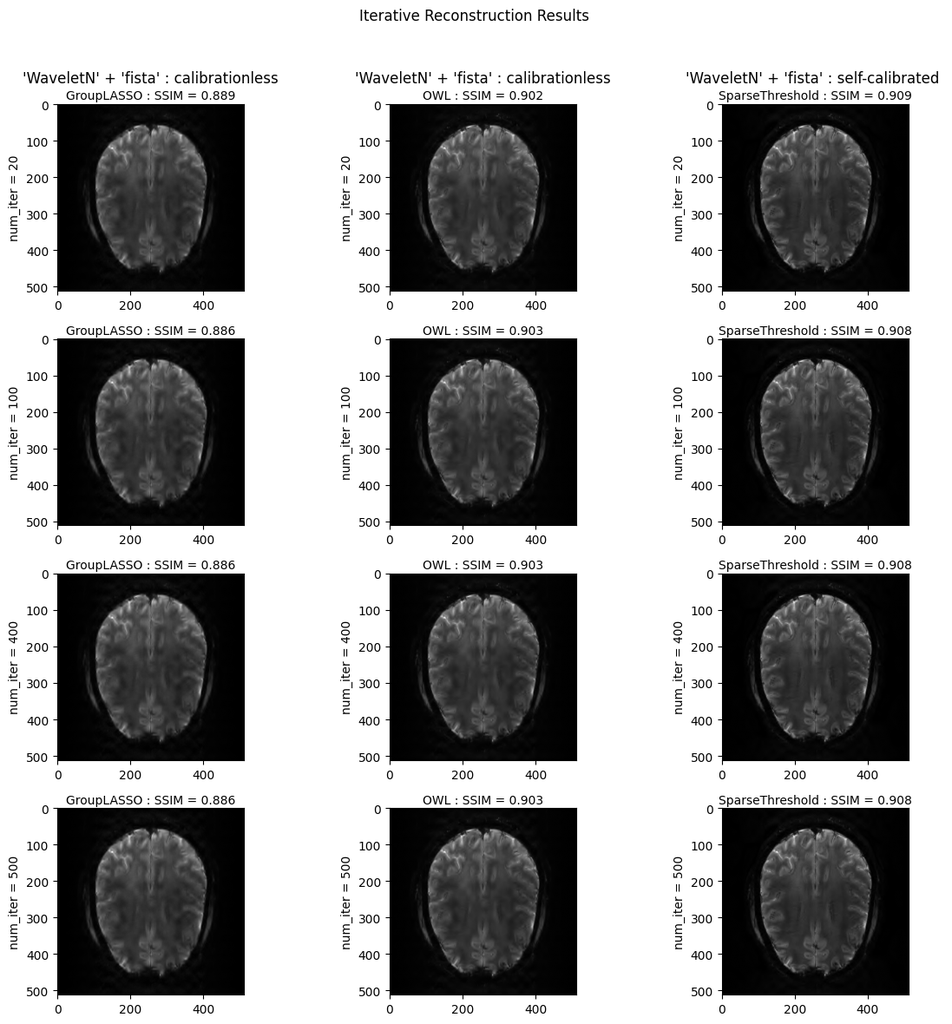

```python
vector_regularizer_op=["GroupLASSO", "OWL", "SparseThreshold"]
vector_num_iterations = [20, 100, 400, 500]
fig, axs = plt.subplots(len(vector_num_iterations), 3, figsize=(12, 12))
matrix_time_computation = np.zeros((len(vector_num_iterations), 3))

for i in range(len(vector_num_iterations)) :
    for j in range(3):
        num_iterations_ = vector_num_iterations[i]

        regularizer_op_ = vector_regularizer_op[j]

        image_rec, recon_ssim, time_computation = reconstruction(regularizer_op_, num_iterations_)

        # 显示重建的图像
        axs[i, j].imshow(np.abs(image_rec), cmap='gray')

        axs[i, j].set_xlabel(f"{regularizer_op_} : SSIM = {recon_ssim:.3f}")
        axs[i, j].xaxis.set_label_position('top')  # 移动 xlabel 到顶部
        axs[i, j].set_ylabel(f"num_iter = {num_iterations_}")

        matrix_time_computation[i][j] = time_computation


axs[0, 0].set_title("'WaveletN' + 'fista' : calibrationless")
axs[0, 1].set_title("'WaveletN' + 'fista' : calibrationless")
axs[0, 2].set_title("'WaveletN' + 'fista' : self-calibrated ")

# Add a main title (suptitle) to the figure
fig.suptitle("Iterative Reconstruction Results")

# Display the figure with adjusted layout
plt.tight_layout(rect=[0, 0, 1, 0.96])  # Adjust layout to fit suptitle
plt.show()
```